# Descubriendo OVNIS (Machine Learning for Hackers)

Disponemos de una base de datos de 60000 avistamientos UFO recopilada por Infochimps.com. Los datos recopilan avistamientos desde hace d?cadas en todo el mundo, aunque principalmente se localizan en USA. Nos gustar?a analizar los datos para intentar averiguar si hay patrones temporales y si existen diferencias significativas entre estados de USA.

Comenzamos cargando los datos desde el fichero tsv

```r
library(ggplot2)
ufo<-read.delim("ufo_awesome.tsv", sep="\t", stringsAsFactors=FALSE,
                header=FALSE, na.strings="")

summary(ufo)
```

```
##       V1                 V2                 V3
##  Length:61870       Length:61870       Length:61870
##  Class :character   Class :character   Class :character
##  Mode  :character   Mode  :character   Mode  :character
##       V4                 V5                 V6
##  Length:61870       Length:61870       Length:61870
##  Class :character   Class :character   Class :character
##  Mode  :character   Mode  :character   Mode  :character
```

```r
head (ufo)
```

```
##         V1       V2                    V3   V4      V5
## 1 19951009 19951009         Iowa City, IA <NA>    <NA>
## 2 19951010 19951011         Milwaukee, WI <NA>  2 min.
## 3 19950101 19950103           Shelton, WA <NA>    <NA>
## 4 19950510 19950510          Columbia, MO <NA>  2 min.
## 5 19950611 19950614           Seattle, WA <NA>    <NA>
## 6 19951025 19951024  Brunswick County, ND <NA> 30 min.
##                                                                                                                                                                                        V6
## 1                                          Man repts. witnessing &quot;flash, followed by a classic UFO, w/ a tailfin at back.&quot; Red color on top half of tailfin. Became triangular.
## 2                                                       Man  on Hwy 43 SW of Milwaukee sees large, bright blue light streak by his car, descend, turn, cross road ahead, strobe. Bizarre!
## 3 Telephoned Report:CA woman visiting daughter witness discs and triangular ships over Squaxin Island in Puget Sound. Dramatic.  Written report, with illustrations, submitted to NUFORC.
## 4                                                    Man repts. son&apos;s bizarre sighting of small humanoid creature in back yard.  Reptd. in Acteon Journal, St. Louis UFO newsletter.
## 5                                                            Anonymous caller repts. sighting 4 ufo&apos;s in NNE sky, 45 deg. above horizon.  (No other facts reptd.  No return tel. #.)
## 6                                                      Sheriff&apos;s office calls to rept. that deputy, 20 mi. SSE of Wilmington,  is looking at peculiar, bright white, strobing light.
```

## Limpieza de datos

### Fechas

```r
names(ufo)<-c("DateOccurred","DateReported","Location","ShortDescription",
              "Duration","LongDescription")
```

Tras etiquetar a las columnas, procedemos a formatear los campos. Utilizamos as.Date para convertir de texto a formato date.

```r
#ufo$DateOccurred<-as.Date(ufo$DateOccurred, format="%Y%m%d")
```

Parece ser que hay problemas con alg?n registro al realizar la conversi?n (datos reales). Necesitamos realizar alg?n tipo de limpieza en los datos

```r
head(ufo[which(nchar(ufo$DateOccurred)!=8 | nchar(ufo$DateReported)!=8),1])
```

```
## [1] "ler@gnv.ifas.ufl.edu"
## [2] "0000"
## [3] "Callers report sighting a number of soft white  balls of lights headingin an easterly directing then changing direction to the west beforespeeding off to the north west."
## [4] "0000"
## [5] "0000"
## [6] "0000"
```

Como podemos ver existen registros donde en los campos de fechas se almacena informaci?n que no es v?lida. Procedamos a filtarlos

```r
good.rows<-ifelse(nchar(ufo$DateOccurred)!=8 | nchar(ufo$DateReported)!=8,FALSE, TRUE)
length(which(!good.rows))
```

```
## [1] 731
```

```r
ufo<-ufo[good.rows,]
```

Eliminamos 731 registros, considerando que partimos de m?s de 61000 no supone una p?rdida importante.

```r
ufo$DateOccurred<-as.Date(ufo$DateOccurred, format="%Y%m%d")
```

Ahora la conversi?n ha t?nido ?xito.

### Localizaci?n

El siguiente paso consiste en intentar extraer mediante el uso de expresiones regulares informaci?n sobre la localizaci?n de cada observaci?n

```r
get.location<-function(l) {
  split.location<-tryCatch(strsplit(l,",")[[1]], error= function(e) return(c(NA, NA)))
  clean.location<-gsub("^ ","",split.location)
  if (length(clean.location)>2) {
    return(c(NA,NA))
  }
  else {
    return(clean.location)
  }
}


city.state<-lapply(ufo$Location, get.location)
head(city.state)
```

```
## [[1]]
## [1] "Iowa City" "IA"
##
## [[2]]
## [1] "Milwaukee" "WI"
##
## [[3]]
## [1] "Shelton" "WA"
##
## [[4]]
## [1] "Columbia" "MO"
##
## [[5]]
## [1] "Seattle" "WA"
##
## [[6]]
## [1] "Brunswick County" "ND"
```

De esta manera disponemos de una lista de localidades y estados de cada observaci?n. El siguiente paso es incorporar esa informaci?n a la tabla.

```r
location.matrix<-do.call(rbind, city.state)
ufo<-transform(ufo, USCity=location.matrix[,1], USState=tolower(location.matrix[,2]),
               stringsAsFactors=FALSE)
summary(ufo)
```

```
##   DateOccurred        DateReported         Location
##  Min.   :1400-06-30   Length:61139       Length:61139
##  1st Qu.:1999-09-15   Class :character   Class :character
##  Median :2003-12-15   Mode  :character   Mode  :character
##  Mean   :2001-02-10
##  3rd Qu.:2007-06-21
##  Max.   :2010-08-30
##  ShortDescription     Duration         LongDescription
##  Length:61139       Length:61139       Length:61139
##  Class :character   Class :character   Class :character
##  Mode  :character   Mode  :character   Mode  :character
##
##
##
##     USCity            USState
##  Length:61139       Length:61139
##  Class :character   Class :character
##  Mode  :character   Mode  :character
##
##
##
```

De esta manera hemos a?adido dos columnas nuevas con la informaci?n al dataframe.

A continuaci?n, marcamos como NA los estados y ciudades que no pertenecen a USA (Canada)

```r
us.states<-c("ak","al","ar","az","ca","co","ct","de","fl","ga","hi","ia","id","il",
             "in","ks","ky","la","ma","md","me","mi","mn","mo","ms","mt","nc","nd","ne","nh",
             "nj","nm","nv","ny","oh","ok","or","pa","ri","sc","sd","tn","tx","ut","va","vt",
             "wa","wi","wv","wy")

ufo$USState<-us.states[match(ufo$USState,us.states)]
ufo$USCity[is.na(ufo$USState)]<-NA
```

Y eliminamos esos registros

```r
ufo.us<-subset(ufo, !is.na(USState))
head(ufo.us)
```

```
##   DateOccurred DateReported              Location ShortDescription
## 1   1995-10-09     19951009         Iowa City, IA             <NA>
## 2   1995-10-10     19951011         Milwaukee, WI             <NA>
## 3   1995-01-01     19950103           Shelton, WA             <NA>
## 4   1995-05-10     19950510          Columbia, MO             <NA>
## 5   1995-06-11     19950614           Seattle, WA             <NA>
## 6   1995-10-25     19951024  Brunswick County, ND             <NA>
##   Duration
## 1     <NA>
## 2   2 min.
## 3     <NA>
## 4   2 min.
## 5     <NA>
## 6  30 min.
##                                                                                                                                                                           LongDescription
## 1                                          Man repts. witnessing &quot;flash, followed by a classic UFO, w/ a tailfin at back.&quot; Red color on top half of tailfin. Became triangular.
## 2                                                       Man  on Hwy 43 SW of Milwaukee sees large, bright blue light streak by his car, descend, turn, cross road ahead, strobe. Bizarre!
## 3 Telephoned Report:CA woman visiting daughter witness discs and triangular ships over Squaxin Island in Puget Sound. Dramatic.  Written report, with illustrations, submitted to NUFORC.
## 4                                                    Man repts. son&apos;s bizarre sighting of small humanoid creature in back yard.  Reptd. in Acteon Journal, St. Louis UFO newsletter.
## 5                                                            Anonymous caller repts. sighting 4 ufo&apos;s in NNE sky, 45 deg. above horizon.  (No other facts reptd.  No return tel. #.)
## 6                                                      Sheriff&apos;s office calls to rept. that deputy, 20 mi. SSE of Wilmington,  is looking at peculiar, bright white, strobing light.
##             USCity USState
## 1        Iowa City      ia
## 2        Milwaukee      wi
## 3          Shelton      wa
## 4         Columbia      mo
## 5          Seattle      wa
## 6 Brunswick County      nd
```

## Agregando y organizando los datos

Una vez hemos formateado la informaci?n podemos comenzar con el an?lisis de los datos. Lo primero que hacemos es comprobar c?mo se distribuyen las fechas de las observaciones.

```r
summary(ufo.us$DateOccurred)
```

```
##         Min.      1st Qu.       Median         Mean      3rd Qu.
## "1400-06-30" "1999-09-06" "2004-01-10" "2001-02-13" "2007-07-26"
##         Max.         NA's
## "2010-08-30"          "1"
```

Parece ser que la primera fecha parece un dato an?malo. Lo verificamos con un histograma.

```
## stat_bin: binwidth defaulted to range/30. Use 'binwidth = x' to adjust this.
```

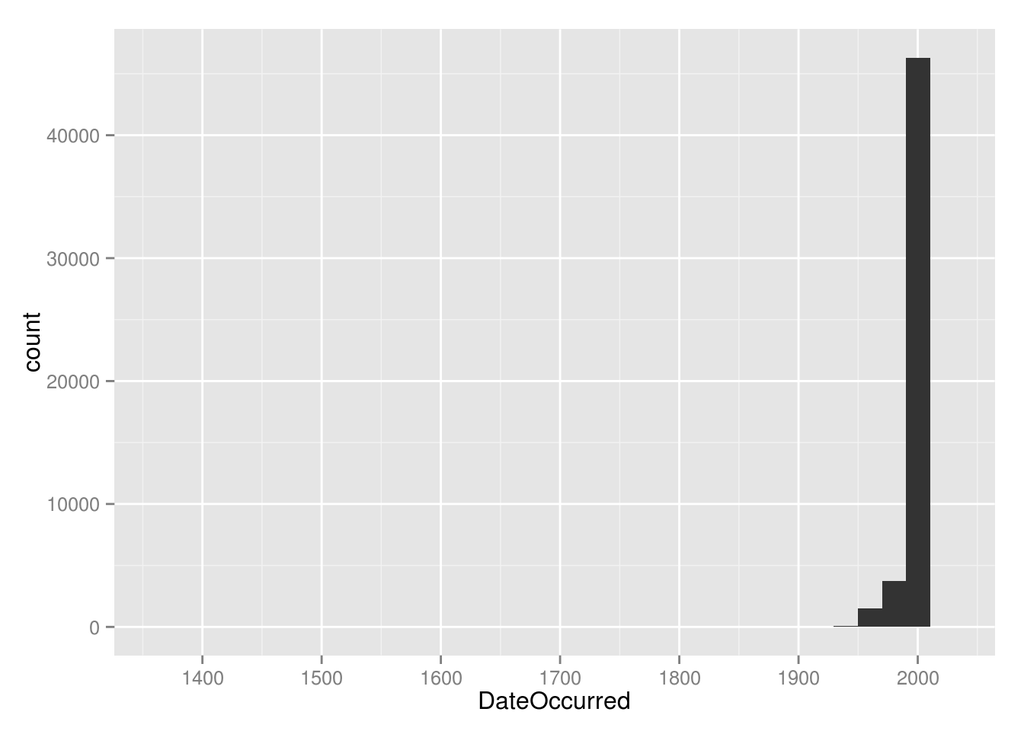

```r
ggplot(ufo.us, aes(x=DateOccurred))+geom_histogram()
```

Ciertamente, el histograma as? lo demuestra, as? que procedemos a filtrar datos antiguos.

```r
ufo.us<-subset(ufo.us, DateOccurred>=as.Date("1990-01-01"))
nrow(ufo.us)
```

```
## [1] 46347
```

Con este filtro nos quedamos con cerca de 46000 observaciones. El histograma respresenta ahora mejor la informaci?n a ser tratada.

```
## stat_bin: binwidth defaulted to range/30. Use 'binwidth = x' to adjust this.
```

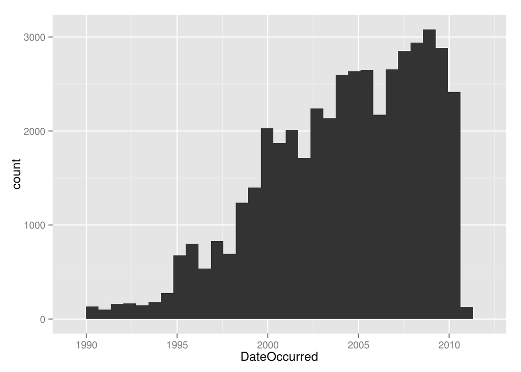

```r
ggplot(ufo.us, aes(x=DateOccurred))+geom_histogram()
```

```r
ufo.us$YearMonth<-strftime(ufo.us$DateOccurred, format="%Y-%m")
```

```r
require (plyr)
sightings.counts<-ddply(ufo.us,.(USState,YearMonth), nrow)
head(sightings.counts)
```

```
##   USState YearMonth V1
## 1      ak   1990-01  1
## 2      ak   1990-03  1
## 3      ak   1990-05  1
## 4      ak   1993-11  1
## 5      ak   1994-11  1
## 6      ak   1995-01  1
```

Sin embargo tenemos el problema de que los meses sin avistamientos no aparecen. Por lo tanto debemos crear de manera manual esas entradas a 0.

```r
date.range<-seq.Date(from=as.Date(min(ufo.us$DateOccurred)),
                     to=as.Date(max(ufo.us$DateOccurred)), by="month")
date.strings<-strftime(date.range, "%Y-%m")
```

Cruzamos las fechas con los estados para producir las posibles combinaciones.

```r
states.dates<-lapply(us.states,function(s) cbind(s,date.strings))
states.dates<-data.frame(do.call(rbind, states.dates), stringsAsFactors=FALSE)
head(states.dates)
```

```
##    s date.strings
## 1 ak      1990-01
## 2 ak      1990-02
## 3 ak      1990-03
## 4 ak      1990-04
## 5 ak      1990-05
## 6 ak      1990-06
```

Con “merge” mezclamos las dos tablas, las que no se rellenen se complentan con “NA”

```r
all.sightings<-merge(states.dates,sightings.counts,by.x=c("s","date.strings"),
                     by.y=c("USState","YearMonth"),all=TRUE)
head(all.sightings)
```

```
##    s date.strings V1
## 1 ak      1990-01  1
## 2 ak      1990-02 NA
## 3 ak      1990-03  1
## 4 ak      1990-04 NA
## 5 ak      1990-05  1
## 6 ak      1990-06 NA
```

Ahora podemos ver que los meses sin avistamientos est?n a NA. Lo ?ltimo que nos falta es cambiar los “NA” por 0, y formatear correcatemente las columnas de fecha y estado. Adem?s de dar nombres significativos a las columnas.

```r
names(all.sightings)<-c("State","YearMonth","Sightings")
all.sightings$Sightings[is.na(all.sightings$Sightings)]<-0
all.sightings$YearMonth<-as.Date(rep(date.range,length(us.states)))
all.sightings$State<-as.factor(toupper(all.sightings$State))
```

Finalmente podemos digujar un gr?fico donde podamos observar de manera conjunta la evoluci?n de los avistamientos para todos los estados en el periodo de tiempo deseado.

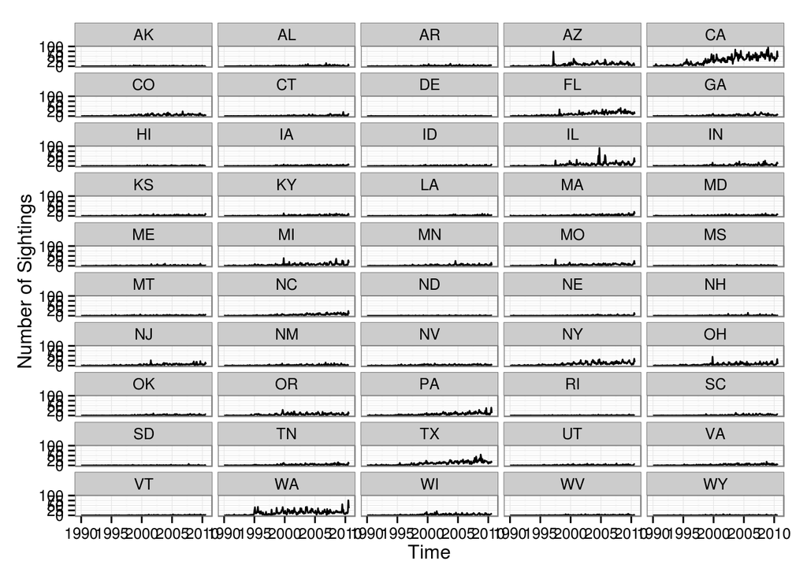

```r
ggplot(all.sightings, aes(x=YearMonth,y=Sightings))+
  geom_line(aes())+
  facet_wrap(~State,nrow=10,ncol=5)+ #partimos en 50 plots
  theme_bw()+ # tema
    xlab("Time")+ylab("Number of Sightings")
```